# Part I - (Loan Data from Prosper)

## Introduction

This data set contains 113,937 loans with 81 variables on each loan, including loan amount, borrower rate (or interest rate), current loan status, borrower income, and many others. This project is part of the requirements for the Udacity Data Analyst Degree Certification.

## Preliminary Wrangling

```python
#importing all packages and set plots to be embedded inline
import numpy as np
import pandas as pd
import matplotlib.pyplot as plt
import seaborn as sb

%matplotlib inline
```

```python
#loading in the dataset
loan_data = pd.read_csv('prosperLoanData.csv')
loan_data.head()
```

|  | ListingKey | ListingNumber | ListingCreationDate | CreditGrade | Term | LoanStatus | ClosedDate | BorrowerAPR | BorrowerRate | LenderYield | ... | LP_ServiceFees | LP_CollectionFees | LP_GrossPrincipalLoss | LP_NetPrincipalLoss | LP_NonPrincipalRecoverypayments | PercentFunded | Recommendations | InvestmentFromFriendsCount | InvestmentFromFriendsAmount | Investors |
| --- | --- | --- | --- | --- | --- | --- | --- | --- | --- | --- | --- | --- | --- | --- | --- | --- | --- | --- | --- | --- | --- |
| 0 | 1021339766868145413AB3B | 193129 | 2007-08-26 19:09:29.263000000 | C | 36 | Completed | 2009-08-14 00:00:00 | 0.16516 | 0.1580 | 0.1380 | ... | -133.18 | 0.0 | 0.0 | 0.0 | 0.0 | 1.0 | 0 | 0 | 0.0 | 258 |
| 1 | 10273602499503308B223C1 | 1209647 | 2014-02-27 08:28:07.900000000 | NaN | 36 | Current | NaN | 0.12016 | 0.0920 | 0.0820 | ... | 0.00 | 0.0 | 0.0 | 0.0 | 0.0 | 1.0 | 0 | 0 | 0.0 | 1 |
| 2 | 0EE9337825851032864889A | 81716 | 2007-01-05 15:00:47.090000000 | HR | 36 | Completed | 2009-12-17 00:00:00 | 0.28269 | 0.2750 | 0.2400 | ... | -24.20 | 0.0 | 0.0 | 0.0 | 0.0 | 1.0 | 0 | 0 | 0.0 | 41 |
| 3 | 0EF5356002482715299901A | 658116 | 2012-10-22 11:02:35.010000000 | NaN | 36 | Current | NaN | 0.12528 | 0.0974 | 0.0874 | ... | -108.01 | 0.0 | 0.0 | 0.0 | 0.0 | 1.0 | 0 | 0 | 0.0 | 158 |
| 4 | 0F023589499656230C5E3E2 | 909464 | 2013-09-14 18:38:39.097000000 | NaN | 36 | Current | NaN | 0.24614 | 0.2085 | 0.1985 | ... | -60.27 | 0.0 | 0.0 | 0.0 | 0.0 | 1.0 | 0 | 0 | 0.0 | 20 |

5 rows × 81 columns

```python
loan_data
```

[output not shown]

113937 rows × 81 columns

```python
loan_data.info()
```

```
<class 'pandas.core.frame.DataFrame'>
RangeIndex: 113937 entries, 0 to 113936
Data columns (total 81 columns):
ListingKey                             113937 non-null object
ListingNumber                          113937 non-null int64
ListingCreationDate                    113937 non-null object
CreditGrade                            28953 non-null object
Term                                   113937 non-null int64
LoanStatus                             113937 non-null object
ClosedDate                             55089 non-null object
BorrowerAPR                            113912 non-null float64
BorrowerRate                           113937 non-null float64
LenderYield                            113937 non-null float64
EstimatedEffectiveYield                84853 non-null float64
EstimatedLoss                          84853 non-null float64
EstimatedReturn                        84853 non-null float64
ProsperRating (numeric)                84853 non-null float64
ProsperRating (Alpha)                  84853 non-null object
ProsperScore                           84853 non-null float64
ListingCategory (numeric)              113937 non-null int64
BorrowerState                          108422 non-null object
Occupation                             110349 non-null object
EmploymentStatus                       111682 non-null object
EmploymentStatusDuration               106312 non-null float64
IsBorrowerHomeowner                    113937 non-null bool
CurrentlyInGroup                       113937 non-null bool
GroupKey                               13341 non-null object
DateCreditPulled                       113937 non-null object
CreditScoreRangeLower                  113346 non-null float64
CreditScoreRangeUpper                  113346 non-null float64
FirstRecordedCreditLine                113240 non-null object
CurrentCreditLines                     106333 non-null float64
OpenCreditLines                        106333 non-null float64
TotalCreditLinespast7years             113240 non-null float64
OpenRevolvingAccounts                  113937 non-null int64
OpenRevolvingMonthlyPayment            113937 non-null float64
InquiriesLast6Months                   113240 non-null float64
TotalInquiries                         112778 non-null float64
CurrentDelinquencies                   113240 non-null float64
AmountDelinquent                       106315 non-null float64
```

[output cut: 31 more lines]

```
LP_CustomerPayments                    113937 non-null float64
LP_CustomerPrincipalPayments           113937 non-null float64
LP_InterestandFees                     113937 non-null float64
LP_ServiceFees                         113937 non-null float64
LP_CollectionFees                      113937 non-null float64
LP_GrossPrincipalLoss                  113937 non-null float64
LP_NetPrincipalLoss                    113937 non-null float64
LP_NonPrincipalRecoverypayments        113937 non-null float64
PercentFunded                          113937 non-null float64
Recommendations                        113937 non-null int64
InvestmentFromFriendsCount             113937 non-null int64
InvestmentFromFriendsAmount            113937 non-null float64
Investors                              113937 non-null int64
dtypes: bool(3), float64(50), int64(11), object(17)
memory usage: 68.1+ MB
```

```python
#dropping null values in needed columns
loan_data = loan_data.dropna(subset = ['DebtToIncomeRatio', 'EmploymentStatus', 'Occupation',
                                      'BorrowerAPR'], how = 'any')
```

```python
#changing 'LoanStatus' data type to category
loan_data['LoanStatus'] = loan_data.LoanStatus.astype('category')
```

```python
#changing 'EmploymentStatus' data type to category
loan_data['EmploymentStatus'] = loan_data.EmploymentStatus.astype('category')
```

```python
loan_data.info()
```

```
<class 'pandas.core.frame.DataFrame'>
Int64Index: 101824 entries, 0 to 113936
Data columns (total 81 columns):
ListingKey                             101824 non-null object
ListingNumber                          101824 non-null int64
ListingCreationDate                    101824 non-null object
CreditGrade                            25480 non-null object
Term                                   101824 non-null int64
LoanStatus                             101824 non-null category
ClosedDate                             48620 non-null object
BorrowerAPR                            101824 non-null float64
BorrowerRate                           101824 non-null float64
LenderYield                            101824 non-null float64
EstimatedEffectiveYield                76224 non-null float64
EstimatedLoss                          76224 non-null float64
EstimatedReturn                        76224 non-null float64
ProsperRating (numeric)                76224 non-null float64
ProsperRating (Alpha)                  76224 non-null object
ProsperScore                           76224 non-null float64
ListingCategory (numeric)              101824 non-null int64
BorrowerState                          97752 non-null object
Occupation                             101824 non-null object
EmploymentStatus                       101824 non-null category
EmploymentStatusDuration               96561 non-null float64
IsBorrowerHomeowner                    101824 non-null bool
CurrentlyInGroup                       101824 non-null bool
GroupKey                               11229 non-null object
DateCreditPulled                       101824 non-null object
CreditScoreRangeLower                  101822 non-null float64
CreditScoreRangeUpper                  101822 non-null float64
FirstRecordedCreditLine                101822 non-null object
CurrentCreditLines                     96570 non-null float64
OpenCreditLines                        96570 non-null float64
TotalCreditLinespast7years             101822 non-null float64
OpenRevolvingAccounts                  101824 non-null int64
OpenRevolvingMonthlyPayment            101824 non-null float64
InquiriesLast6Months                   101822 non-null float64
TotalInquiries                         101821 non-null float64
CurrentDelinquencies                   101822 non-null float64
AmountDelinquent                       96572 non-null float64
```

[output cut: 31 more lines]

```
LP_CustomerPayments                    101824 non-null float64
LP_CustomerPrincipalPayments           101824 non-null float64
LP_InterestandFees                     101824 non-null float64
LP_ServiceFees                         101824 non-null float64
LP_CollectionFees                      101824 non-null float64
LP_GrossPrincipalLoss                  101824 non-null float64
LP_NetPrincipalLoss                    101824 non-null float64
LP_NonPrincipalRecoverypayments        101824 non-null float64
PercentFunded                          101824 non-null float64
Recommendations                        101824 non-null int64
InvestmentFromFriendsCount             101824 non-null int64
InvestmentFromFriendsAmount            101824 non-null float64
Investors                              101824 non-null int64
dtypes: bool(3), category(2), float64(50), int64(11), object(15)
memory usage: 60.3+ MB
```

```python
loan_data.duplicated().sum()
```

```
0
```

```python
loan_data['ListingKey'].duplicated().sum()
```

```
730
```

```python
loan_data[loan_data['ListingKey'].duplicated()]
```

|  | ListingKey | ListingNumber | ListingCreationDate | CreditGrade | Term | LoanStatus | ClosedDate | BorrowerAPR | BorrowerRate | LenderYield | ... | LP_ServiceFees | LP_CollectionFees | LP_GrossPrincipalLoss | LP_NetPrincipalLoss | LP_NonPrincipalRecoverypayments | PercentFunded | Recommendations | InvestmentFromFriendsCount | InvestmentFromFriendsAmount | Investors |
| --- | --- | --- | --- | --- | --- | --- | --- | --- | --- | --- | --- | --- | --- | --- | --- | --- | --- | --- | --- | --- | --- |
| 9 | 0F043596202561788EA13D5 | 1023355 | 2013-12-02 10:43:39.117000000 | NaN | 36 | Current | NaN | 0.07620 | 0.0629 | 0.0529 | ... | -16.77 | 0.0 | 0.0 | 0.0 | 0.0 | 1.0 | 0 | 0 | 0.0 | 1 |
| 999 | 0A0635972629771021E38F3 | 1055932 | 2013-12-18 14:25:17.053000000 | NaN | 60 | Current | NaN | 0.17710 | 0.1535 | 0.1435 | ... | 0.00 | 0.0 | 0.0 | 0.0 | 0.0 | 1.0 | 0 | 0 | 0.0 | 1 |
| 2539 | 2D2635984503681189056B4 | 1097584 | 2014-01-11 07:50:08.037000000 | NaN | 60 | Current | NaN | 0.14528 | 0.1224 | 0.1124 | ... | 0.00 | 0.0 | 0.0 | 0.0 | 0.0 | 1.0 | 0 | 0 | 0.0 | 1 |
| 4942 | 4B7E3590031274113F1FD34 | 927246 | 2013-09-26 09:35:36.317000000 | NaN | 36 | Current | NaN | 0.35356 | 0.3134 | 0.3034 | ... | -15.98 | 0.0 | 0.0 | 0.0 | 0.0 | 1.0 | 0 | 0 | 0.0 | 40 |
| 5971 | 2EC635885737984509D5366 | 894748 | 2013-09-16 06:59:12.297000000 | NaN | 60 | Current | NaN | 0.18555 | 0.1620 | 0.1520 | ... | -33.14 | 0.0 | 0.0 | 0.0 | 0.0 | 1.0 | 0 | 0 | 0.0 | 1 |
| 6385 | 083235967773321272C26B9 | 1066466 | 2013-12-10 13:39:07.220000000 | NaN | 36 | Current | NaN | 0.11563 | 0.0879 | 0.0779 | ... | -8.49 | 0.0 | 0.0 | 0.0 | 0.0 | 1.0 | 0 | 0 | 0.0 | 1 |
| 7415 | 5A2F35875117483773421B0 | 875616 | 2013-08-21 07:25:22.360000000 | NaN | 60 | Current | NaN | 0.24589 | 0.2209 | 0.2109 | ... | -32.43 | 0.0 | 0.0 | 0.0 | 0.0 | 1.0 | 0 | 0 | 0.0 | 75 |
| 7538 | 09AD35918712001025AC1BD | 969821 | 2013-10-24 13:21:31.607000000 | NaN | 36 | Current | NaN | 0.20524 | 0.1685 | 0.1585 | ... | -8.41 | 0.0 | 0.0 | 0.0 | 0.0 | 1.0 | 0 | 0 | 0.0 | 1 |
| 8683 | 8E8B35952875791221BB463 | 1047993 | 2013-11-25 08:46:13.073000000 | NaN | 36 | Current | NaN | 0.20524 | 0.1685 | 0.1585 | ... | -3.07 | 0.0 | 0.0 | 0.0 | 0.0 | 1.0 | 0 | 0 | 0.0 | 1 |
| 8925 | 359F36006583392169BF3F3 | 1138422 | 2014-01-14 16:09:07.770000000 | NaN | 36 | Current | NaN | 0.22966 | 0.1920 | 0.1820 | ... | 0.00 | 0.0 | 0.0 | 0.0 | 0.0 | 1.0 | 0 | 0 | 0.0 | 1 |
| 9102 | 9A4A36004039348126F769C | 1100572 | 2014-01-12 08:01:41.417000000 | NaN | 36 | Current | NaN | 0.27817 | 0.2394 | 0.2294 | ... | 0.00 | 0.0 | 0.0 | 0.0 | 0.0 | 1.0 | 0 | 0 | 0.0 | 17 |
| 9281 | 47C1359638497431975670B | 1057901 | 2013-12-06 11:44:58.283000000 | NaN | 36 | Current | NaN | 0.34588 | 0.3059 | 0.2959 | ... | -1.70 | 0.0 | 0.0 | 0.0 | 0.0 | 1.0 | 0 | 0 | 0.0 | 1 |
| 10036 | 0C6036000415689128E6FE2 | 1101199 | 2014-01-12 10:10:41.447000000 | NaN | 36 | Current | NaN | 0.18990 | 0.1535 | 0.1435 | ... | -12.74 | 0.0 | 0.0 | 0.0 | 0.0 | 1.0 | 0 | 0 | 0.0 | 1 |
| 10401 | 68153589168873924D3A78D | 898052 | 2013-09-12 12:53:22.680000000 | NaN | 36 | Current | NaN | 0.29537 | 0.2566 | 0.2466 | ... | -16.12 | 0.0 | 0.0 | 0.0 | 0.0 | 1.0 | 0 | 0 | 0.0 | 1 |
| 10467 | 0CF635895559781161C1DF0 | 890514 | 2013-09-07 06:25:14.057000000 | NaN | 36 | Current | NaN | 0.20268 | 0.1660 | 0.1560 | ... | -9.55 | 0.0 | 0.0 | 0.0 | 0.0 | 1.0 | 0 | 0 | 0.0 | 1 |
| 11635 | 9F3F3598049868065A10243 | 1069928 | 2013-12-13 08:05:03.380000000 | NaN | 60 | Current | NaN | 0.15449 | 0.1314 | 0.1214 | ... | 0.00 | 0.0 | 0.0 | 0.0 | 0.0 | 1.0 | 0 | 0 | 0.0 | 1 |
| 11889 | 04A53597159795718CE3A26 | 1063352 | 2013-12-09 18:54:29.140000000 | NaN | 36 | Current | NaN | 0.15223 | 0.1239 | 0.1139 | ... | -7.43 | 0.0 | 0.0 | 0.0 | 0.0 | 1.0 | 0 | 0 | 0.0 | 1 |
| 11979 | 693435900525895578B8728 | 900913 | 2013-09-16 18:45:59.473000000 | NaN | 60 | Current | NaN | 0.14760 | 0.1249 | 0.1149 | ... | -49.79 | 0.0 | 0.0 | 0.0 | 0.0 | 1.0 | 0 | 0 | 0.0 | 256 |
| 12379 | 9F493599966105917027FC0 | 1116810 | 2014-01-06 09:16:14.857000000 | NaN | 60 | Current | NaN | 0.20040 | 0.1765 | 0.1665 | ... | -5.52 | 0.0 | 0.0 | 0.0 | 0.0 | 1.0 | 0 | 0 | 0.0 | 1 |
| 12595 | 16D935877639843867B8CD7 | 877625 | 2013-08-22 20:45:22.927000000 | NaN | 36 | Current | NaN | 0.18479 | 0.1485 | 0.1385 | ... | -16.29 | 0.0 | 0.0 | 0.0 | 0.0 | 1.0 | 0 | 0 | 0.0 | 1 |
| 12694 | 5DB83600871174699C124B4 | 1114591 | 2014-01-16 11:16:58.077000000 | NaN | 60 | Current | NaN | 0.15844 | 0.1355 | 0.1255 | ... | -19.18 | 0.0 | 0.0 | 0.0 | 0.0 | 1.0 | 0 | 0 | 0.0 | 1 |
| 12780 | 5DB83600871174699C124B4 | 1114591 | 2014-01-16 11:16:58.077000000 | NaN | 60 | Current | NaN | 0.15844 | 0.1355 | 0.1255 | ... | -19.18 | 0.0 | 0.0 | 0.0 | 0.0 | 1.0 | 0 | 0 | 0.0 | 1 |
| 12956 | 059135904162159071EA963 | 925803 | 2013-09-26 06:08:44.510000000 | NaN | 36 | Current | NaN | 0.23540 | 0.1980 | 0.1880 | ... | -19.74 | 0.0 | 0.0 | 0.0 | 0.0 | 1.0 | 0 | 0 | 0.0 | 1 |
| 13322 | 487E36006726969571BB95E | 1111486 | 2014-01-14 17:19:38.497000000 | NaN | 36 | Current | NaN | 0.14853 | 0.1199 | 0.1099 | ... | 0.00 | 0.0 | 0.0 | 0.0 | 0.0 | 1.0 | 0 | 0 | 0.0 | 1 |
| 14071 | 0FE63589666879701965D2E | 898757 | 2013-09-12 14:20:39.077000000 | NaN | 36 | Current | NaN | 0.23233 | 0.1950 | 0.1850 | ... | -15.87 | 0.0 | 0.0 | 0.0 | 0.0 | 1.0 | 0 | 0 | 0.0 | 1 |
| 14114 | 484535954799474542E4235 | 990994 | 2013-11-12 19:31:17.900000000 | NaN | 60 | Current | NaN | 0.23318 | 0.2085 | 0.1985 | ... | -37.43 | 0.0 | 0.0 | 0.0 | 0.0 | 1.0 | 0 | 0 | 0.0 | 1 |
| 14469 | 17E035962771170915118B7 | 1044353 | 2013-12-03 07:26:15.663000000 | NaN | 60 | Current | NaN | 0.25564 | 0.2304 | 0.2204 | ... | -21.99 | 0.0 | 0.0 | 0.0 | 0.0 | 1.0 | 0 | 0 | 0.0 | 1 |
| 14888 | 17A93590655669644DB4C06 | 951186 | 2013-10-02 17:20:16.550000000 | NaN | 60 | Current | NaN | 0.16662 | 0.1435 | 0.1335 | ... | -8.49 | 0.0 | 0.0 | 0.0 | 0.0 | 1.0 | 0 | 0 | 0.0 | 96 |
| 15171 | 081C359727187929726315B | 1090596 | 2013-12-17 04:52:24.187000000 | NaN | 60 | Current | NaN | 0.27308 | 0.2474 | 0.2374 | ... | -3.40 | 0.0 | 0.0 | 0.0 | 0.0 | 1.0 | 0 | 0 | 0.0 | 1 |
| 15855 | 4A2B3589916361549758617 | 926217 | 2013-09-26 07:19:23.177000000 | NaN | 36 | Current | NaN | 0.14816 | 0.1199 | 0.1099 | ... | -17.23 | 0.0 | 0.0 | 0.0 | 0.0 | 1.0 | 0 | 0 | 0.0 | 1 |
| ... | ... | ... | ... | ... | ... | ... | ... | ... | ... | ... | ... | ... | ... | ... | ... | ... | ... | ... | ... | ... | ... |
| 111520 | 91C535951829778912FC637 | 1009196 | 2013-11-11 03:40:51.710000000 | NaN | 60 | Current | NaN | 0.21115 | 0.1870 | 0.1770 | ... | -37.42 | 0.0 | 0.0 | 0.0 | 0.0 | 1.0 | 0 | 0 | 0.0 | 2 |
| 111708 | 7D763589580628208BDA5E7 | 905371 | 2013-09-17 18:04:28.313000000 | NaN | 36 | Current | NaN | 0.18020 | 0.1440 | 0.1340 | ... | -52.56 | 0.0 | 0.0 | 0.0 | 0.0 | 1.0 | 0 | 0 | 0.0 | 1 |
| 111798 | 2C9335960241892503011F7 | 1049386 | 2013-12-11 17:53:12.647000000 | NaN | 60 | Current | NaN | 0.13636 | 0.1139 | 0.1039 | ... | 0.00 | 0.0 | 0.0 | 0.0 | 0.0 | 1.0 | 0 | 0 | 0.0 | 1 |
| 111810 | D2E33595862829977249F5F | 1065219 | 2013-12-02 17:49:30.093000000 | NaN | 36 | Current | NaN | 0.19859 | 0.1620 | 0.1520 | ... | -15.97 | 0.0 | 0.0 | 0.0 | 0.0 | 1.0 | 0 | 0 | 0.0 | 1 |
| 111815 | 2CAE3599816069543EC2541 | 1128831 | 2014-01-08 17:20:36.357000000 | NaN | 60 | Current | NaN | 0.20833 | 0.1840 | 0.1740 | ... | 0.00 | 0.0 | 0.0 | 0.0 | 0.0 | 1.0 | 0 | 0 | 0.0 | 1 |
| 111839 | 2AB8359616126680323CA29 | 1048512 | 2013-11-25 10:07:03.627000000 | NaN | 60 | Current | NaN | 0.16969 | 0.1465 | 0.1365 | ... | -33.79 | 0.0 | 0.0 | 0.0 | 0.0 | 1.0 | 0 | 0 | 0.0 | 1 |
| 111850 | 85B8359189827433103090E | 959620 | 2013-10-25 11:28:26.710000000 | NaN | 36 | Current | NaN | 0.11563 | 0.0879 | 0.0779 | ... | -11.04 | 0.0 | 0.0 | 0.0 | 0.0 | 1.0 | 0 | 0 | 0.0 | 1 |
| 111860 | D4DE35939392928454F5C56 | 996931 | 2013-11-15 12:47:12.287000000 | NaN | 36 | Current | NaN | 0.20933 | 0.1725 | 0.1625 | ... | -21.01 | 0.0 | 0.0 | 0.0 | 0.0 | 1.0 | 0 | 0 | 0.0 | 178 |
| 111890 | 2AEA358216796526862A4CF | 827053 | 2013-07-02 14:09:36.273000000 | NaN | 60 | Current | NaN | 0.17061 | 0.1474 | 0.1374 | ... | -61.42 | 0.0 | 0.0 | 0.0 | 0.0 | 1.0 | 0 | 0 | 0.0 | 135 |
| 111991 | D5143589915934140970B2C | 916391 | 2013-09-16 21:04:08.690000000 | NaN | 36 | Current | NaN | 0.19144 | 0.1550 | 0.1450 | ... | -18.48 | 0.0 | 0.0 | 0.0 | 0.0 | 1.0 | 0 | 0 | 0.0 | 1 |
| 111992 | D51E35932804638501E8036 | 978862 | 2013-11-04 13:30:11.223000000 | NaN | 60 | Current | NaN | 0.17839 | 0.1550 | 0.1450 | ... | -16.60 | 0.0 | 0.0 | 0.0 | 0.0 | 1.0 | 0 | 0 | 0.0 | 95 |
| 112216 | D75A3602316015132A9216A | 1184373 | 2014-02-03 15:21:39.167000000 | NaN | 36 | Current | NaN | 0.16732 | 0.1314 | 0.1214 | ... | 0.00 | 0.0 | 0.0 | 0.0 | 0.0 | 1.0 | 0 | 0 | 0.0 | 1 |
| 112413 | D4293602060815307FAE6FF | 1188953 | 2014-02-10 16:59:57.720000000 | NaN | 60 | Current | NaN | 0.21858 | 0.1940 | 0.1840 | ... | 0.00 | 0.0 | 0.0 | 0.0 | 0.0 | 1.0 | 0 | 0 | 0.0 | 1 |
| 112495 | D4A835935376294376ABA8F | 969859 | 2013-11-01 13:04:51.400000000 | NaN | 36 | Current | NaN | 0.14714 | 0.1189 | 0.1089 | ... | -31.34 | 0.0 | 0.0 | 0.0 | 0.0 | 1.0 | 0 | 0 | 0.0 | 1 |
| 112536 | C92A358761060339096B2DD | 880829 | 2013-08-26 21:11:28.233000000 | NaN | 36 | Current | NaN | 0.14409 | 0.1159 | 0.1059 | ... | -32.50 | 0.0 | 0.0 | 0.0 | 0.0 | 1.0 | 0 | 0 | 0.0 | 1 |
| 112603 | D7C735983829965531D41C3 | 1054075 | 2013-12-17 18:45:28.067000000 | NaN | 60 | Current | NaN | 0.22549 | 0.2010 | 0.1910 | ... | -7.67 | 0.0 | 0.0 | 0.0 | 0.0 | 1.0 | 0 | 0 | 0.0 | 1 |
| 112882 | E3D73599782139936411B7C | 1092778 | 2014-01-07 17:29:00.257000000 | NaN | 60 | Current | NaN | 0.21474 | 0.1905 | 0.1805 | ... | -4.38 | 0.0 | 0.0 | 0.0 | 0.0 | 1.0 | 0 | 0 | 0.0 | 1 |
| 112924 | E429359755806503027BB47 | 1088357 | 2013-12-21 10:38:45.070000000 | NaN | 36 | Current | NaN | 0.18275 | 0.1465 | 0.1365 | ... | 0.00 | 0.0 | 0.0 | 0.0 | 0.0 | 1.0 | 0 | 0 | 0.0 | 1 |
| 112935 | E4A535977459220288CF9E8 | 1091759 | 2013-12-23 10:57:37.223000000 | NaN | 36 | Current | NaN | 0.22108 | 0.1840 | 0.1740 | ... | -12.74 | 0.0 | 0.0 | 0.0 | 0.0 | 1.0 | 0 | 0 | 0.0 | 1 |
| 113136 | D9333592158298812306CFE | 955489 | 2013-10-22 13:38:29.020000000 | NaN | 36 | Current | NaN | 0.14714 | 0.1189 | 0.1089 | ... | -41.97 | 0.0 | 0.0 | 0.0 | 0.0 | 1.0 | 0 | 0 | 0.0 | 1 |
| 113144 | EDD8359046678714347C47F | 942150 | 2013-09-30 11:52:24.563000000 | NaN | 60 | Current | NaN | 0.14760 | 0.1249 | 0.1149 | ... | -37.34 | 0.0 | 0.0 | 0.0 | 0.0 | 1.0 | 0 | 0 | 0.0 | 234 |
| 113218 | F03B3601709314958288970 | 1197011 | 2014-02-15 15:17:33.710000000 | NaN | 36 | Current | NaN | 0.14039 | 0.1119 | 0.1019 | ... | 0.00 | 0.0 | 0.0 | 0.0 | 0.0 | 1.0 | 0 | 0 | 0.0 | 1 |
| 113356 | DF2A359228716263104A4AA | 983181 | 2013-10-15 14:09:17.917000000 | NaN | 36 | Current | NaN | 0.26047 | 0.2225 | 0.2125 | ... | -32.69 | 0.0 | 0.0 | 0.0 | 0.0 | 1.0 | 0 | 0 | 0.0 | 102 |
| 113386 | DF3136001150855929A0752 | 1163997 | 2014-01-27 15:52:52.027000000 | NaN | 36 | Current | NaN | 0.14243 | 0.1139 | 0.1039 | ... | 0.00 | 0.0 | 0.0 | 0.0 | 0.0 | 1.0 | 0 | 0 | 0.0 | 1 |
| 113431 | F60435969051132053F528E | 1071926 | 2013-12-13 13:12:43.283000000 | NaN | 36 | Current | NaN | 0.20524 | 0.1685 | 0.1585 | ... | -8.22 | 0.0 | 0.0 | 0.0 | 0.0 | 1.0 | 0 | 0 | 0.0 | 1 |
| 113468 | F62D35912219342157114FA | 933395 | 2013-09-25 15:33:07.113000000 | NaN | 60 | Current | NaN | 0.22601 | 0.2015 | 0.1915 | ... | -20.28 | 0.0 | 0.0 | 0.0 | 0.0 | 1.0 | 0 | 0 | 0.0 | 1 |
| 113548 | FB6A35999320129979DBBA3 | 1158474 | 2014-01-23 14:33:25.967000000 | NaN | 60 | Current | NaN | 0.22063 | 0.1960 | 0.1860 | ... | 0.00 | 0.0 | 0.0 | 0.0 | 0.0 | 1.0 | 0 | 0 | 0.0 | 1 |
| 113733 | E2303594522341016B8EE15 | 1002326 | 2013-11-07 14:26:31.317000000 | NaN | 60 | Current | NaN | 0.20593 | 0.1819 | 0.1719 | ... | -24.94 | 0.0 | 0.0 | 0.0 | 0.0 | 1.0 | 0 | 0 | 0.0 | 66 |
| 113773 | DE8535960513435199406CE | 1056749 | 2013-12-06 05:43:13.830000000 | NaN | 36 | Current | NaN | 0.16324 | 0.1274 | 0.1174 | ... | -16.79 | 0.0 | 0.0 | 0.0 | 0.0 | 1.0 | 0 | 0 | 0.0 | 1 |
| 113863 | C74335893905744205D4056 | 928893 | 2013-09-26 12:53:34.633000000 | NaN | 36 | Current | NaN | 0.12691 | 0.0990 | 0.0890 | ... | -15.99 | 0.0 | 0.0 | 0.0 | 0.0 | 1.0 | 0 | 0 | 0.0 | 1 |

730 rows × 81 columns

```python
#dropping duplicates in the 'ListingKey' column
loan_data = loan_data.drop_duplicates(subset = "ListingKey")
```

```python
loan_data['ListingCategory (numeric)'] = loan_data['ListingCategory (numeric)'].replace({0: 'Not Available', 1: 'Debt Consolidation',
                                                                             2: 'Home Improvement', 3: 'Business',
                                                                             4: 'Personal Loan', 5: 'Student Use', 6: 'Auto',
                                                                             7: 'Other', 8: 'Baby&Adoption', 9: 'Boat',
                                                                             10: 'Cosmetic Procedure', 11: 'Engagement Ring',
                                                                             12: 'Green Loans', 13: 'Household Expenses',
                                                                             14: 'Large Purchases', 15: 'Medical/Dental',
                                                                             16: 'Motorcycle', 17: 'RV', 18: 'Taxes',
                                                                             19: 'Vacation', 20: 'Wedding Loans'})
loan_data.rename(columns={'ListingCategory (numeric)':'ListingCategory'}, inplace=True)
```

```python
loan_data['ListingCategory'].dtype
```

```
dtype('O')
```

```python
#changing 'ListingCategory' data type to category
loan_data['ListingCategory'] = loan_data.ListingCategory.astype('category')
```

```python
loan_data.describe()
```

|  | ListingNumber | Term | BorrowerAPR | BorrowerRate | LenderYield | EstimatedEffectiveYield | EstimatedLoss | EstimatedReturn | ProsperRating (numeric) | ProsperScore | ... | LP_ServiceFees | LP_CollectionFees | LP_GrossPrincipalLoss | LP_NetPrincipalLoss | LP_NonPrincipalRecoverypayments | PercentFunded | Recommendations | InvestmentFromFriendsCount | InvestmentFromFriendsAmount | Investors |
| --- | --- | --- | --- | --- | --- | --- | --- | --- | --- | --- | --- | --- | --- | --- | --- | --- | --- | --- | --- | --- | --- |
| count | 1.010940e+05 | 101094.000000 | 101094.000000 | 101094.000000 | 101094.000000 | 75494.000000 | 75494.000000 | 75494.000000 | 75494.000000 | 75494.000000 | ... | 101094.000000 | 101094.000000 | 101094.000000 | 101094.000000 | 101094.000000 | 101094.000000 | 101094.000000 | 101094.000000 | 101094.000000 | 101094.000000 |
| mean | 6.300041e+05 | 41.030328 | 0.216850 | 0.190984 | 0.180889 | 0.166914 | 0.078701 | 0.095689 | 4.129547 | 6.082987 | ... | -56.778124 | -14.473292 | 690.370174 | 670.789311 | 25.939827 | 0.998591 | 0.047837 | 0.022484 | 14.937951 | 83.620719 |
| std | 3.211354e+05 | 10.561684 | 0.079895 | 0.074391 | 0.074085 | 0.067721 | 0.046125 | 0.030097 | 1.663470 | 2.357859 | ... | 61.735973 | 110.846856 | 2386.981191 | 2354.633020 | 282.487968 | 0.017881 | 0.308651 | 0.207672 | 266.582866 | 106.231152 |
| min | 3.610000e+02 | 12.000000 | 0.006530 | 0.000000 | -0.010000 | -0.181600 | 0.004900 | -0.181600 | 1.000000 | 1.000000 | ... | -664.870000 | -9274.750000 | -94.200000 | -954.550000 | 0.000000 | 0.700000 | 0.000000 | 0.000000 | 0.000000 | 1.000000 |
| 25% | 4.041430e+05 | 36.000000 | 0.154280 | 0.131400 | 0.121400 | 0.115000 | 0.042000 | 0.074080 | 3.000000 | 4.000000 | ... | -76.940000 | 0.000000 | 0.000000 | 0.000000 | 0.000000 | 1.000000 | 0.000000 | 0.000000 | 0.000000 | 2.000000 |
| 50% | 6.027085e+05 | 36.000000 | 0.207350 | 0.181500 | 0.170000 | 0.157670 | 0.069900 | 0.091200 | 4.000000 | 6.000000 | ... | -36.740000 | 0.000000 | 0.000000 | 0.000000 | 0.000000 | 1.000000 | 0.000000 | 0.000000 | 0.000000 | 46.000000 |
| 75% | 8.837435e+05 | 36.000000 | 0.278170 | 0.249800 | 0.239200 | 0.219000 | 0.108000 | 0.115000 | 5.000000 | 8.000000 | ... | -15.220000 | 0.000000 | 0.000000 | 0.000000 | 0.000000 | 1.000000 | 0.000000 | 0.000000 | 0.000000 | 121.000000 |
| max | 1.255149e+06 | 60.000000 | 0.423950 | 0.360000 | 0.340000 | 0.319900 | 0.366000 | 0.266700 | 7.000000 | 11.000000 | ... | 32.060000 | 0.000000 | 25000.000000 | 25000.000000 | 21117.900000 | 1.012500 | 24.000000 | 20.000000 | 25000.000000 | 1189.000000 |

8 rows × 60 columns

```python
loan_data.info()
```

```
<class 'pandas.core.frame.DataFrame'>
Int64Index: 101094 entries, 0 to 113936
Data columns (total 81 columns):
ListingKey                             101094 non-null object
ListingNumber                          101094 non-null int64
ListingCreationDate                    101094 non-null object
CreditGrade                            25480 non-null object
Term                                   101094 non-null int64
LoanStatus                             101094 non-null category
ClosedDate                             48608 non-null object
BorrowerAPR                            101094 non-null float64
BorrowerRate                           101094 non-null float64
LenderYield                            101094 non-null float64
EstimatedEffectiveYield                75494 non-null float64
EstimatedLoss                          75494 non-null float64
EstimatedReturn                        75494 non-null float64
ProsperRating (numeric)                75494 non-null float64
ProsperRating (Alpha)                  75494 non-null object
ProsperScore                           75494 non-null float64
ListingCategory                        101094 non-null category
BorrowerState                          97022 non-null object
Occupation                             101094 non-null object
EmploymentStatus                       101094 non-null category
EmploymentStatusDuration               95831 non-null float64
IsBorrowerHomeowner                    101094 non-null bool
CurrentlyInGroup                       101094 non-null bool
GroupKey                               11227 non-null object
DateCreditPulled                       101094 non-null object
CreditScoreRangeLower                  101092 non-null float64
CreditScoreRangeUpper                  101092 non-null float64
FirstRecordedCreditLine                101092 non-null object
CurrentCreditLines                     95840 non-null float64
OpenCreditLines                        95840 non-null float64
TotalCreditLinespast7years             101092 non-null float64
OpenRevolvingAccounts                  101094 non-null int64
OpenRevolvingMonthlyPayment            101094 non-null float64
InquiriesLast6Months                   101092 non-null float64
TotalInquiries                         101091 non-null float64
CurrentDelinquencies                   101092 non-null float64
AmountDelinquent                       95842 non-null float64
```

[output cut: 31 more lines]

```
LP_CustomerPayments                    101094 non-null float64
LP_CustomerPrincipalPayments           101094 non-null float64
LP_InterestandFees                     101094 non-null float64
LP_ServiceFees                         101094 non-null float64
LP_CollectionFees                      101094 non-null float64
LP_GrossPrincipalLoss                  101094 non-null float64
LP_NetPrincipalLoss                    101094 non-null float64
LP_NonPrincipalRecoverypayments        101094 non-null float64
PercentFunded                          101094 non-null float64
Recommendations                        101094 non-null int64
InvestmentFromFriendsCount             101094 non-null int64
InvestmentFromFriendsAmount            101094 non-null float64
Investors                              101094 non-null int64
dtypes: bool(3), category(3), float64(50), int64(10), object(15)
memory usage: 59.2+ MB
```

```python
print(loan_data['CreditScoreRangeUpper'].to_csv(index=False))
```

[output not shown]

[output cut: 101039 more lines]

[output not shown]

```python
print(loan_data['CreditScoreRangeLower'].to_csv(index=False))
```

[output not shown]

[output cut: 101039 more lines]

[output not shown]

### What is the structure of your dataset?

The dataset originally comprises of 113,937 loan records with 81 features. However, after wrangling, 101094 records remained with 81 features.

### What is/are the main feature(s) of interest in your dataset?

The loan status and the loan amount.

### What features in the dataset do you think will help support your investigation into your feature(s) of interest?

These are features that I think can support my investigation, defined as explained in the data dictionary:

1. Term: The length of the loan expressed in months.
2. LoanStatus: The current status of the loan: Cancelled, Chargedoff, Completed, Current, Defaulted, FinalPaymentInProgress, PastDue. The PastDue status will be accompanied by a delinquency bucket.
3. BorrowerRate: The Borrower's interest rate for this loan.
4. ProsperRating (numeric): The Prosper Rating assigned at the time the listing was created: 0 - N/A, 1 - HR, 2 - E, 3 - D, 4 - C, 5 - B, 6 - A, 7 - AA. Applicable for loans originated after July 2009.
5. ProsperRating (Alpha): The Prosper Rating assigned at the time the listing was created between AA - HR. Applicable for loans originated after July 2009.
6. BorrowerState: The two letter abbreviation of the state of the address of the borrower at the time the Listing was created.
7. Occupation: The Occupation selected by the Borrower at the time they created the listing.
8. EmploymentStatus: The employment status of the borrower at the time they posted the listing.
9. DebtToIncomeRatio: The debt to income ratio of the borrower at the time the credit profile was pulled. This value is Null if the debt to income ratio is not available. This value is capped at 10.01 (any debt to income ratio larger than 1000% will be returned as 1001%).
10. StatedMonthlyIncome: The monthly income the borrower stated at the time the listing was created.
11. LoanOriginalAmount: The origination amount of the loan.
12. LoanOriginationQuarter: The quarter in which the loan was originated.

## Univariate Exploration

Question: What is the loan status of the borrowers?

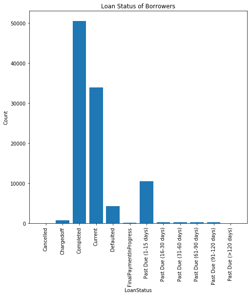

```python
#returning the series with unique values for loan status
x = loan_data['LoanStatus'].unique()

#returning the series with the frequency count of each unique value
y = loan_data['LoanStatus'].value_counts(sort=True)

#plotting the bar chart in desired size
plt.figure(figsize= (8, 8))
plt.bar(x, y)

#labeling the axes
plt.xlabel('LoanStatus')
plt.ylabel('Count')
plt.title("Loan Status of Borrowers")

#using xticks to rotate the category labels counter-clockwise (not axes)
plt.xticks(rotation= 90)

#displaying the bar chart
plt.show()
```

```python
loan_data['LoanStatus'].value_counts()
```

```
Current                   50466
Completed                 33894
Chargedoff                10463
Defaulted                  4249
Past Due (1-15 days)        709
Past Due (31-60 days)       320
Past Due (91-120 days)      277
Past Due (61-90 days)       274
Past Due (16-30 days)       241
FinalPaymentInProgress      185
Past Due (>120 days)         14
Cancelled                     2
Name: LoanStatus, dtype: int64
```

Question: What are the listing categories?

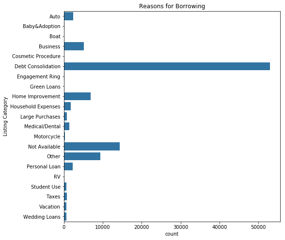

```python
#plotting a horizontal bar chart for the listing categories
plt.figure(figsize= (8, 8))
sb.countplot(y= 'ListingCategory', data= loan_data, color= sb.color_palette()[0])
plt.ylabel('Listing Category')
plt.title("Reasons for Borrowing");
```

Observation: The highest reason for taking the loans is for loan consolidation.

Question: What is the distribution of loans in quarters?

```python
loan_data['LoanOriginationQuarter'].value_counts()
```

```
Q4 2013    12498
Q1 2014    10315
Q3 2013     8640
Q2 2013     6642
Q3 2012     5091
Q2 2012     4490
Q2 2008     4058
Q4 2012     4043
Q1 2012     3855
Q4 2011     3405
Q1 2013     3288
Q3 2008     3139
Q2 2007     3098
Q1 2008     2982
Q1 2007     2974
Q3 2011     2742
Q3 2007     2582
Q4 2007     2491
Q4 2006     2238
Q2 2011     2202
Q1 2011     1575
Q3 2006     1437
Q4 2010     1419
Q2 2010     1345
Q4 2009     1292
Q3 2010     1127
Q1 2010     1101
Q3 2009      544
Q4 2008      465
Q2 2009       13
Q1 2006        2
Q2 2006        1
Name: LoanOriginationQuarter, dtype: int64
```

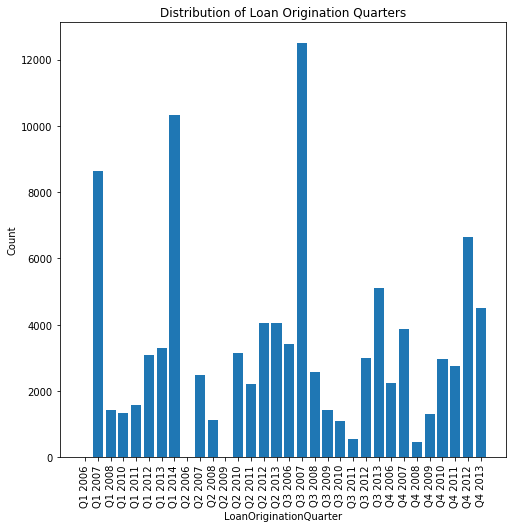

```python
#returning the series with unique values for loan origination quarter
y = loan_data['LoanOriginationQuarter'].value_counts(sort= True)

#returning the series with frequency count of each unique value
x = loan_data['LoanOriginationQuarter'].unique()

#plotting the bar chart in the desired size
plt.figure(figsize= (8, 8))
plt.bar(x,y)

#labeling the axes
plt.xlabel('LoanOriginationQuarter')
plt.ylabel('Count')
plt.title("Distribution of Loan Origination Quarters")

#using xticks to rotate the category labels counter-clockwise (not axes)
plt.xticks(rotation= 90)

#displaying the barchart
plt.show()
```

Question: What states have the most borrowers?

```
''
```

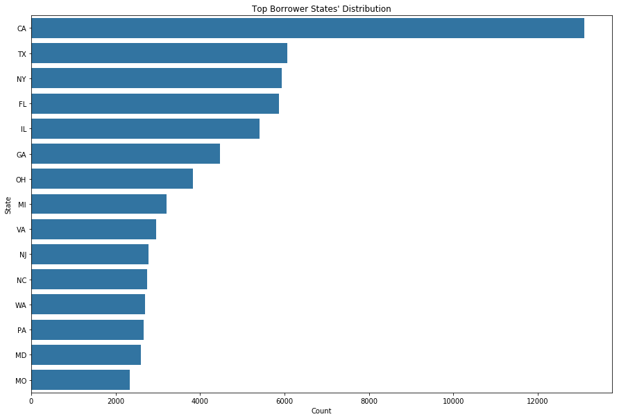

```python
#plotting a horizontal bar chart for the top borrower states
plt.figure(figsize = [15, 10])
arrange = loan_data['BorrowerState'].value_counts().iloc[:15].index
sb.countplot(data= loan_data, y= 'BorrowerState', color = sb.color_palette()[0], order = arrange)
plt.title("Top Borrower States' Distribution")
plt.xlabel("Count")
plt.ylabel("State")
;
```

```
''
```

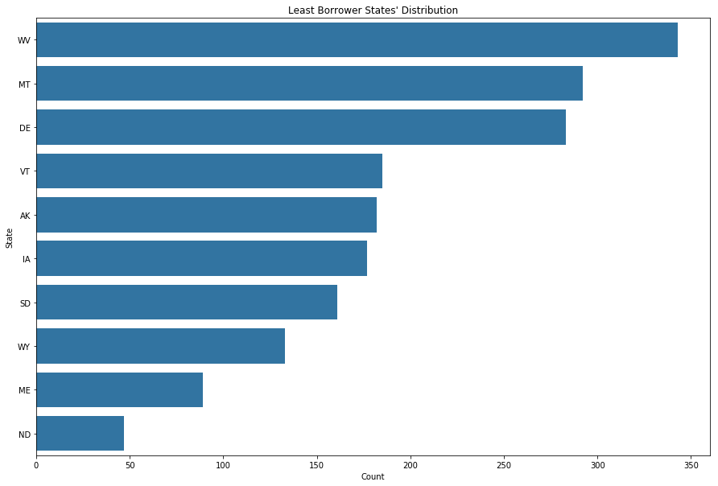

```python
#plotting a horizontal bar chart for the least borrower states
plt.figure(figsize = [15, 10])
arrange = loan_data['BorrowerState'].value_counts().iloc[-10:].index
sb.countplot(data= loan_data, y= 'BorrowerState', color = sb.color_palette()[0], order = arrange)
plt.title("Least Borrower States' Distribution")
plt.xlabel("Count")
plt.ylabel("State")
;
```

Observation: California has the highest number of borrowers. Texas, New York, and Florida follow with about 6000 borrowers each. North Dakota has the least number of borrowers.

Question: What are the employment statuses of the borrowers?

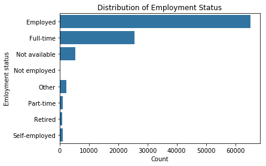

```python
#plotting a horizontal bar chart for the employment statuses
sb.countplot(y= 'EmploymentStatus', data =loan_data, color= sb.color_palette()[0])
plt.title("Distribution of Employment Status")
plt.xlabel("Count")
plt.ylabel("Emloyment status");
```

Observation: Most of the borrowers are employed and working full-time.

Question: What is the distribution of the loan terms?

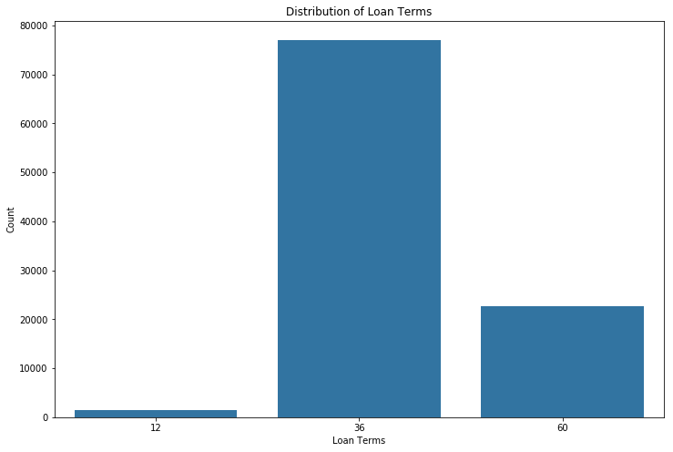

```python
#plotting a bar chart showing the loan terms
plt.figure(figsize = [12, 8])
arrangement = [12, 36, 60]
sb.countplot(data= loan_data, x= 'Term', color = sb.color_palette()[0], order = arrangement)
plt.title("Distribution of Loan Terms")
plt.xlabel("Loan Terms")
plt.ylabel("Count");
```

Observation: Most of the loans have a 36-month term.

Question: What is the distribution for the borrowers' monthly income?

```python
loan_data['StatedMonthlyIncome'].describe()
```

```
count    101094.000000
mean       5683.137009
std        4979.282324
min           0.000000
25%        3333.333333
50%        4800.000000
75%        6916.666667
max      483333.333333
Name: StatedMonthlyIncome, dtype: float64
```

```python
loan_data['StatedMonthlyIncome'].max()+600
```

```
483933.33333300002
```

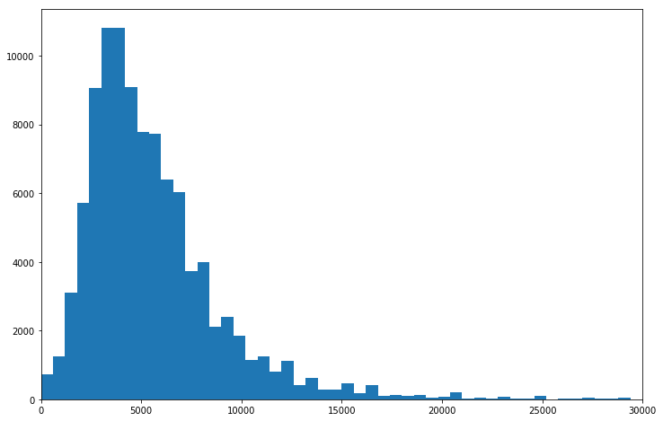

```python
#plotting a histogram showing borrowers' 'StatedMonthlyIncome'
plt.figure(figsize = [12, 8])
binsize= np.arange(0, 1750603, 600)
plt.hist(data= loan_data, x = 'StatedMonthlyIncome', bins= binsize)
plt.xlim(0, 30000);
```

Observation: About 5000 people in the dataset earn more than 10000 monthly.

Question: What are the borrowers' debt to income ratio?

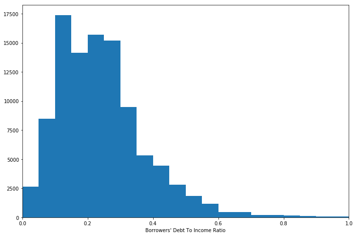

```python
#plotting a histogram for the borrowers' 'DebtToIncomeRatio'
plt.figure(figsize = [12, 8])
binsize= np.arange(0, loan_data['DebtToIncomeRatio'].max()+0.05, 0.05)
plt.hist(data= loan_data, x = 'DebtToIncomeRatio', bins= binsize)
plt.xlim(0, 1)
plt.xlabel("Borrowers' Debt To Income Ratio");
```

Observation: The lowest debt to income ratio ranges from 0 to 0.2

Question: What is the distribution of original loan amounts?

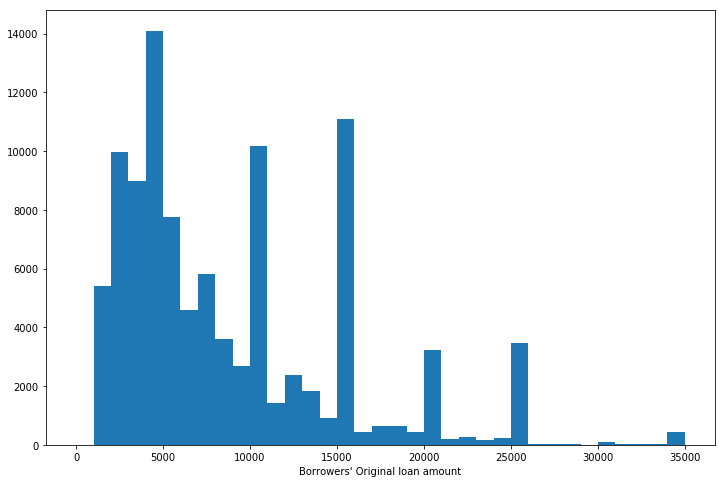

```python
#plotting a histogram for original loan amounts
plt.figure(figsize = [12, 8])
binsize= np.arange(0, loan_data['LoanOriginalAmount'].max()+1000, 1000)
plt.hist(data= loan_data, x = 'LoanOriginalAmount', bins= binsize)
plt.xlabel("Borrowers' Original loan amount");
```

Question: What are the borrower rates?

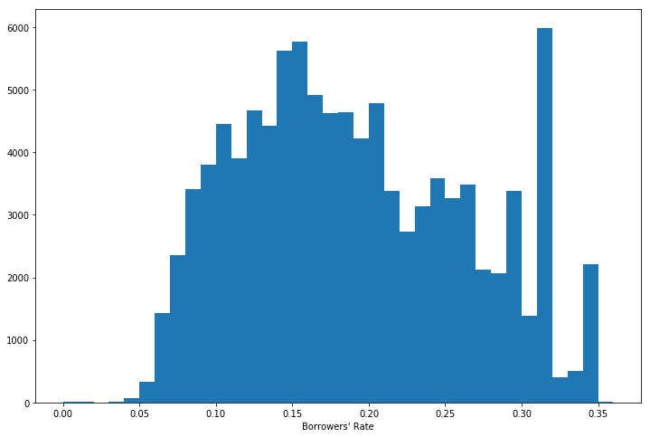

```python
#plotting a histogram for the Borrowers' Rate
plt.figure(figsize = [12, 8])
binsize= np.arange(0, loan_data['BorrowerRate'].max()+0.01, 0.01)
plt.hist(data= loan_data, x = 'BorrowerRate', bins= binsize)
plt.xlabel("Borrowers' Rate");
```

Observation: The highest borrower rate is between 0.30 and 0.35

Question: What are the various occupations?

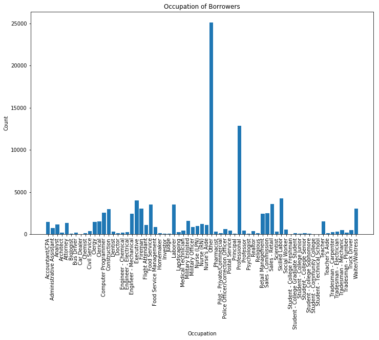

```python
#returning the series with unique values for occupation
x = loan_data['Occupation'].unique()

#returning the series with the frequency count of each unique value
y = loan_data['Occupation'].value_counts(sort=True)

#plotting the bar chart in desired size
plt.figure(figsize=(12, 8))
plt.bar(x, y)

#labeling the axes
plt.xlabel('Occupation')
plt.ylabel('Count')
plt.title("Occupation of Borrowers")

#using xticks to rotate the category labels counter-clockwise (not axes)
plt.xticks(rotation= 90)

#displaying the bar chart
plt.show()
```

People in the 'other' category for borrowers' occupation have the highest number.

## Bivariate Exploration

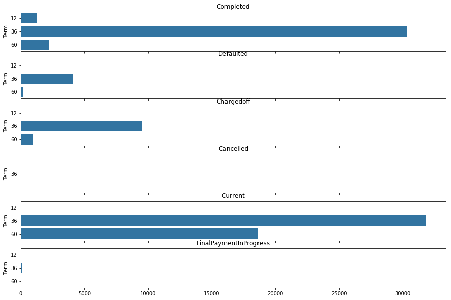

```python
#plotting a horizontal bar chart for terms of different loan statuses
fig, ax= plt.subplots(nrows= 6, figsize= (15,10), sharex = True)

sb.countplot(data= loan_data.query('LoanStatus=="Completed"'), y='Term', ax=ax[0], color = sb.color_palette()[0])
ax[0].set_title('Completed')
ax[0].set_xlabel('')

sb.countplot(data= loan_data.query('LoanStatus=="Defaulted"'), y='Term', ax=ax[1], color = sb.color_palette()[0])
ax[1].set_title('Defaulted')
ax[1].set_xlabel('')

sb.countplot(data= loan_data.query('LoanStatus=="Chargedoff"'), y='Term', ax=ax[2], color = sb.color_palette()[0])
ax[2].set_title('Chargedoff')
ax[2].set_xlabel('')

sb.countplot(data= loan_data.query('LoanStatus=="Cancelled"'), y='Term', ax=ax[3], color = sb.color_palette()[0])
ax[3].set_title('Cancelled')
ax[3].set_xlabel('')

sb.countplot(data= loan_data.query('LoanStatus=="Current"'), y='Term', ax=ax[4], color = sb.color_palette()[0])
ax[4].set_title('Current')
ax[4].set_xlabel('')

sb.countplot(data= loan_data.query('LoanStatus=="FinalPaymentInProgress"'), y='Term', ax=ax[5], color = sb.color_palette()[0])
ax[5].set_title('FinalPaymentInProgress')
ax[5].set_xlabel('')

plt.show();
```

Observation: Having known that the highest percentage of loans are 36-term loans, 'current' 36-term loans have the highest category for loan status.

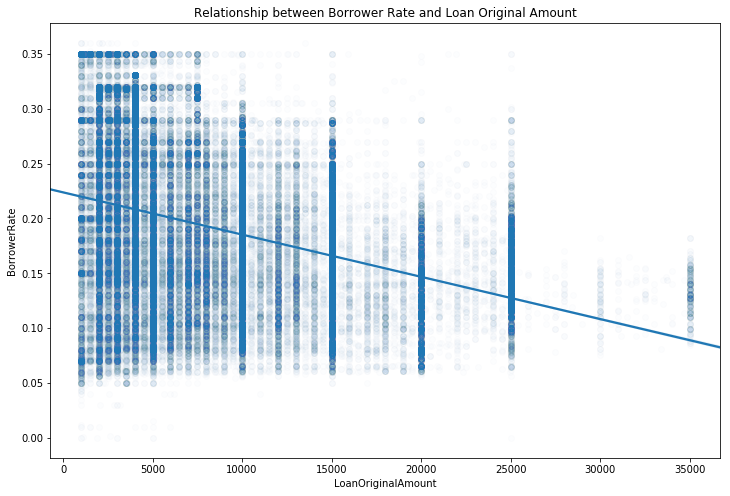

```python
#checking the relationship between borrower rate and loan original amount
plt.figure(figsize = [12, 8])
sb.regplot(data = loan_data, x = 'LoanOriginalAmount', y = 'BorrowerRate', scatter_kws= {'alpha':0.01})
plt.title('Relationship between Borrower Rate and Loan Original Amount');
```

Observation: The higher the loan original amount, the lower the borrower rate.

```python
#getting another dataframe for the borrower states and their loan statuses
states = pd.DataFrame(loan_data.groupby('BorrowerState')['LoanStatus'].value_counts(),
                      columns= ['LoanStatus'])
states.rename(columns= {'LoanStatus': 'Count'}, inplace= True)
states.reset_index(inplace= True)
states.head()
```

|  | BorrowerState | LoanStatus | Count |
| --- | --- | --- | --- |
| 0 | AK | Current | 94 |
| 1 | AK | Completed | 68 |
| 2 | AK | Chargedoff | 14 |
| 3 | AK | Defaulted | 3 |
| 4 | AK | FinalPaymentInProgress | 2 |

```python
#filtering out the top 4 borrower states
filter_states = states.query("BorrowerState == 'CA' or BorrowerState == 'TX' or BorrowerState== 'NY' or BorrowerState== 'FL'")
```

[output not shown]

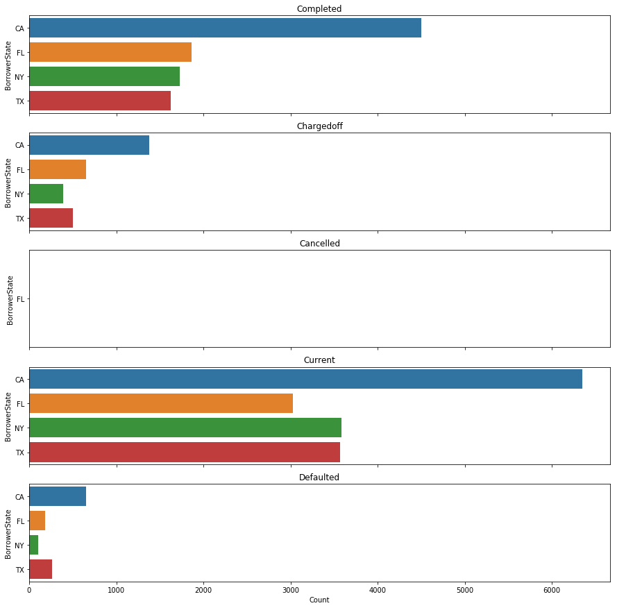

```python
#plotting bar charts for the different loan statuses in the top borrower states
fig, ax= plt.subplots(nrows=5, figsize = [15,15], sharex = True)

sb.barplot(data= filter_states.query('LoanStatus=="Completed"'), y= 'BorrowerState', x= 'Count', ax=ax[0])
ax[0].set_title('Completed')
ax[0].set_xlabel('')

sb.barplot(data= filter_states.query('LoanStatus=="Chargedoff"'), y= 'BorrowerState', x= 'Count', ax=ax[1])
ax[1].set_title('Chargedoff')
ax[1].set_xlabel('')

sb.barplot(data= filter_states.query('LoanStatus=="Cancelled"'), y= 'BorrowerState', x= 'Count', ax=ax[2])
ax[2].set_title('Cancelled')
ax[2].set_xlabel('')

sb.barplot(data= filter_states.query('LoanStatus=="Current"'), y= 'BorrowerState', x= 'Count', ax=ax[3])
ax[3].set_title('Current')
ax[3].set_xlabel('')

sb.barplot(data= filter_states.query('LoanStatus=="Defaulted"'), y= 'BorrowerState', x= 'Count', ax=ax[4])
ax[4].set_title('Defaulted')
ax[4].set_xlabel('Count')
```

Observation: The highest loan status in California is 'current'.

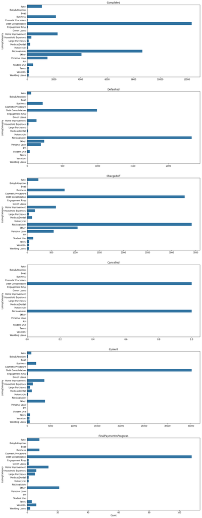

```python
fig, ax= plt.subplots(nrows= 6, figsize= (15,45), sharex= False)

sb.countplot(data= loan_data.query('LoanStatus=="Completed"'), y='ListingCategory', ax=ax[0], color = sb.color_palette()[0])
ax[0].set_title('Completed')
ax[0].set_xlabel('')

sb.countplot(data= loan_data.query('LoanStatus=="Defaulted"'), y='ListingCategory', ax=ax[1], color = sb.color_palette()[0])
ax[1].set_title('Defaulted')
ax[1].set_xlabel('')

sb.countplot(data= loan_data.query('LoanStatus=="Chargedoff"'), y='ListingCategory', ax=ax[2], color = sb.color_palette()[0])
ax[2].set_title('Chargedoff')
ax[2].set_xlabel('')

sb.countplot(data= loan_data.query('LoanStatus=="Cancelled"'), y='ListingCategory', ax=ax[3], color = sb.color_palette()[0])
ax[3].set_title('Cancelled')
ax[3].set_xlabel('')

sb.countplot(data= loan_data.query('LoanStatus=="Current"'), y='ListingCategory', ax=ax[4], color = sb.color_palette()[0])
ax[4].set_title('Current')
ax[4].set_xlabel('')

sb.countplot(data= loan_data.query('LoanStatus=="FinalPaymentInProgress"'), y='ListingCategory', ax=ax[5],
             color = sb.color_palette()[0])
ax[5].set_title('FinalPaymentInProgress')
ax[5].set_xlabel('Count')

plt.show();
```

Observation: The highest loan status for debt consolidation is 'current'.

```python
numeric_variables= [ 'LoanOriginalAmount', 'DebtToIncomeRatio', 'StatedMonthlyIncome', 'BorrowerRate']
```

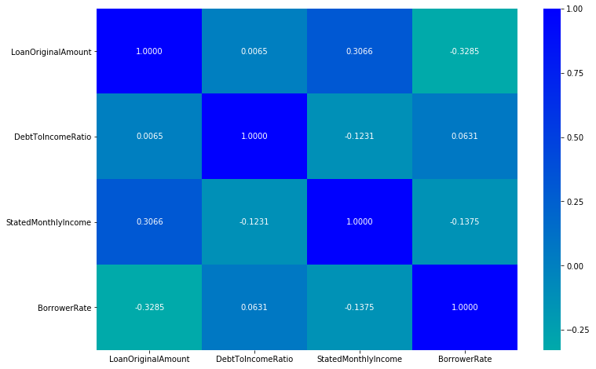

```python
#getting the correlation between numeric variables
plt.figure(figsize= [12, 8])
sb.heatmap(loan_data[numeric_variables].corr(), annot= True, fmt= '.4f',
           cmap= 'winter_r', center= 0);
```

Observation: The correlation between Loan Original Amount and Debt to Income Ratio is 0.0065, The correlation between Loan Original Amount and Stated Monthly Income is 0.3066, and The correlation between Loan Original Amount and Borrower Rate is -0.3285

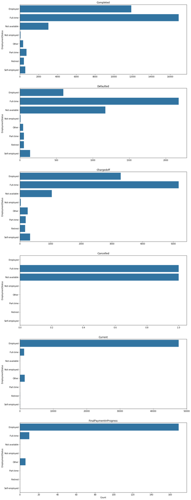

```python
#plotting bar charts for the employments statuses in different loan statuses
fig, ax= plt.subplots(nrows= 6, figsize= (15,45), sharex= False)

sb.countplot(data= loan_data.query('LoanStatus=="Completed"'), y='EmploymentStatus', ax=ax[0], color = sb.color_palette()[0])
ax[0].set_title('Completed')
ax[0].set_xlabel('')

sb.countplot(data= loan_data.query('LoanStatus=="Defaulted"'), y='EmploymentStatus', ax=ax[1], color = sb.color_palette()[0])
ax[1].set_title('Defaulted')
ax[1].set_xlabel('')

sb.countplot(data= loan_data.query('LoanStatus=="Chargedoff"'), y='EmploymentStatus', ax=ax[2], color = sb.color_palette()[0])
ax[2].set_title('Chargedoff')
ax[2].set_xlabel('')

sb.countplot(data= loan_data.query('LoanStatus=="Cancelled"'), y='EmploymentStatus', ax=ax[3], color = sb.color_palette()[0])
ax[3].set_title('Cancelled')
ax[3].set_xlabel('')

sb.countplot(data= loan_data.query('LoanStatus=="Current"'), y='EmploymentStatus', ax=ax[4], color = sb.color_palette()[0])
ax[4].set_title('Current')
ax[4].set_xlabel('')

sb.countplot(data= loan_data.query('LoanStatus=="FinalPaymentInProgress"'), y='EmploymentStatus', ax=ax[5],
             color = sb.color_palette()[0])
ax[5].set_title('FinalPaymentInProgress')
ax[5].set_xlabel('Count')

plt.show();
```

Observation: Most loans taken by people doing full-time work are completed.

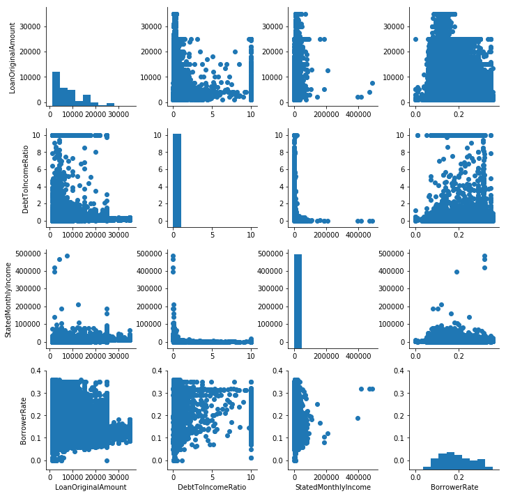

```python
g= sb.PairGrid(data= loan_data, vars= numeric_variables)
g.map_diag(plt.hist)
g.map_offdiag(plt.scatter);
```

Observation: There is a negative correlation between borrower rate and loan amount while there is a positive correlation between loan original amount and the stated monthly income.

Question

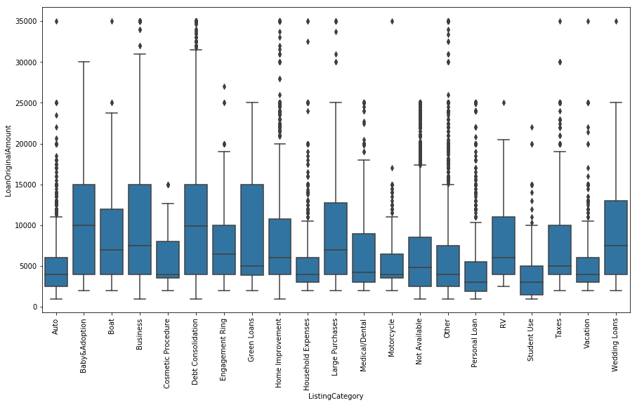

```python
#boxplot for loan amounts of different listing categories
plt.figure(figsize = [15, 8])
sb.boxplot(data = loan_data, x = 'ListingCategory', y = 'LoanOriginalAmount', color = sb.color_palette()[0]);
plt.xticks(rotation = 90);
```

Observation: Green loans, debt consolidation, business, and baby & adoption had the highest loan amounts.

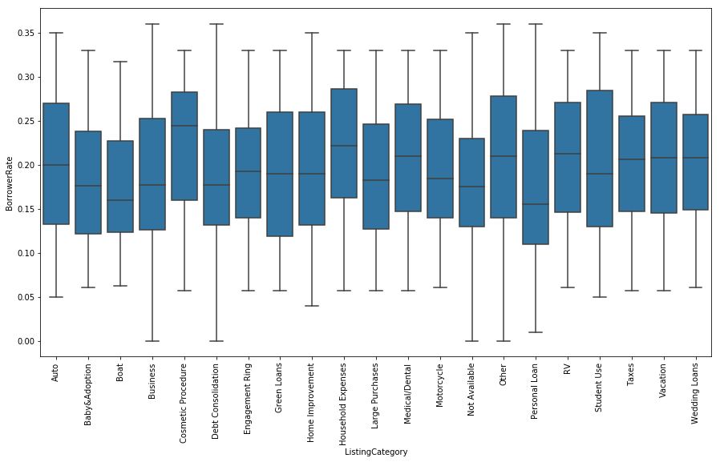

```python
#boxplot for borrower rates of different listing categories
plt.figure(figsize = [15, 8])
sb.boxplot(data = loan_data, x = 'ListingCategory', y = 'BorrowerRate', color = sb.color_palette()[0]);
plt.xticks(rotation = 90);
```

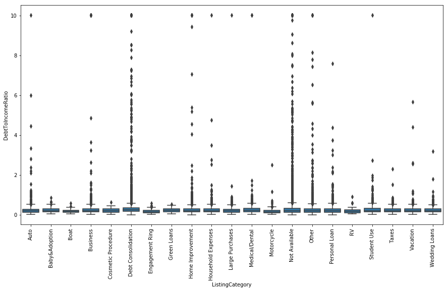

```python
#boxplot for debt to income ratio of different listing categories
plt.figure(figsize = [15, 8])
sb.boxplot(data = loan_data, x = 'ListingCategory', y = 'DebtToIncomeRatio', color = sb.color_palette()[0]);
plt.xticks(rotation = 90);
```

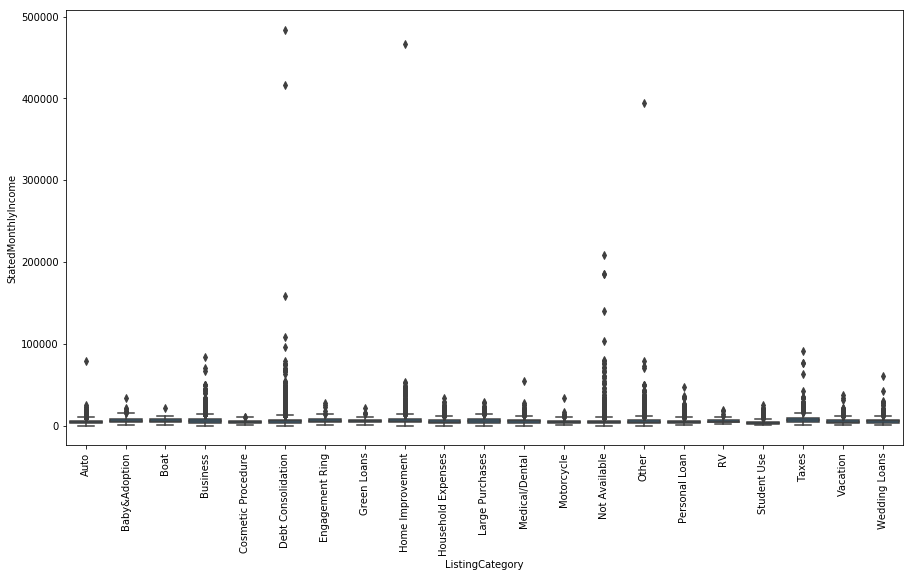

```python
#boxplot for stated monthly income of different listing categories
plt.figure(figsize = [15, 8])
sb.boxplot(data = loan_data, x = 'ListingCategory', y = 'StatedMonthlyIncome', color = sb.color_palette()[0]);
plt.xticks(rotation = 90);
```

### Talk about some of the relationships you observed in this part of the investigation. How did the feature(s) of interest vary with other features in the dataset?

There is a negative correlation between borrower rate and loan amount while there is a positive correlation between loan original amount and the stated monthly income. The higher the loan original amount, the lower the borrower rate. Green loans, debt consolidation, business, and baby & adoption had the highest loan amounts. Most loans taken by people doing full-time work are completed. The highest loan status for debt consolidation is 'current'. The highest loan status in California is 'current'. 'Current' 36-term loans have the highest category for loan status.

## Multivariate Exploration

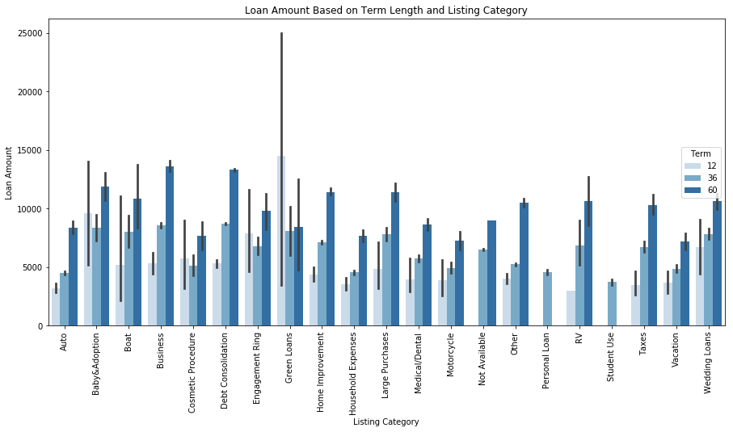

```python
#bar plot for Loan Amount Based on Term Length and Listing Category
fig = plt.figure(figsize = [15,7])
ax = sb.barplot(data = loan_data, x = 'ListingCategory', y = 'LoanOriginalAmount',  hue = 'Term', palette = 'Blues')
plt.title('Loan Amount Based on Term Length and Listing Category')
plt.xlabel('Listing Category')
plt.ylabel('Loan Amount')
plt.xticks(rotation = 90)
ax.legend(loc='center right', title='Term')
plt.show();
```

Observation: The highest green loan amount is a 12-term loan.

Question

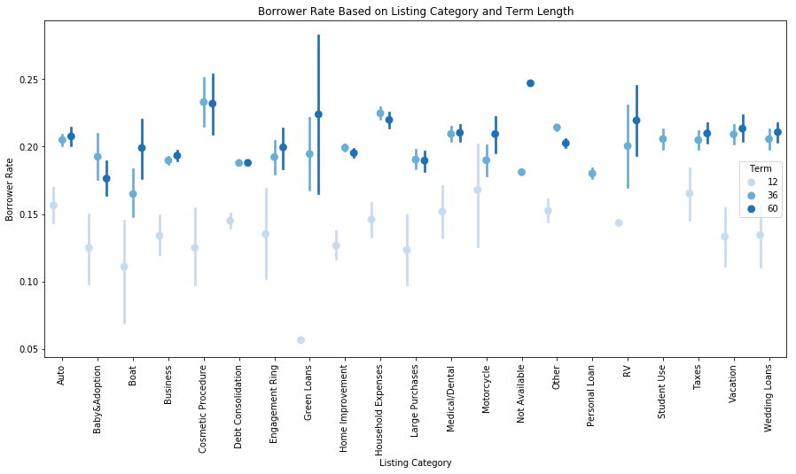

```python
#bar plot for Borrower Rate Based on Listing Category and Term Length
fig = plt.figure(figsize = [15,7])
ax = sb.pointplot(data = loan_data, x = 'ListingCategory', y = 'BorrowerRate',  hue = 'Term',
           palette = 'Blues', linestyles = '', dodge = 0.5)
plt.title('Borrower Rate Based on Listing Category and Term Length')
plt.xlabel('Listing Category')
plt.ylabel('Borrower Rate')
plt.xticks(rotation = 90)
ax.legend(loc='center right', title='Term')
plt.show();
```

Observation: Shorter term loans have lower borrower rates.

### Talk about some of the relationships you observed in this part of the investigation. Were there features that strengthened each other in terms of looking at your feature(s) of interest?

One of the multivariate visualizations corroborates the fact that green loans have the highest loan amount. The highest green loan amount is a 12-term loan.

### Were there any interesting or surprising interactions between features?

Shorter term loans have lower borrower rates.

## Conclusions

There is a negative correlation between borrower rate and loan amount while there is a positive correlation between loan original amount and the stated monthly income. The higher the loan original amount, the lower the borrower rate. Green loans, debt consolidation, business, and baby & adoption had the highest loan amounts. Most loans taken by people doing full-time work are completed. The highest loan status for debt consolidation is 'current'. The highest loan status in California is 'current'. 'Current' 36-term loans have the highest category for loan status. Green loans have the highest loan amount. The highest green loan amount is a 12-term loan.

References: Stackoverflow, Udacity Classroom